# Interactive Mapping in R

April 11, 2019

*"everything is related to everything else, but near things are more related than distant things."*

Tobler's first law of geography.

## Requirements

Please install the following packages which are required for static and dynamic mapping:

```r
install.packages("leaflet")
install.packages("rgdal")
install.packages("raster")
```

and then, invoke them:

```r
library(leaflet)
library(rgdal)
library(raster)
```

## Basics: Tiles

*"A tile map (raster or vector) is a map displayed in a browser by seamlessly joining dozens of individually requested image files over the internet."*

Let's create a simple map:

```r
library(leaflet)   # load the library
mymap<-leaflet() %>%
  addTiles # images you are going to see
mymap   #check the map
```

[interactive chart not shown]

Now, it is time to explore different tiles! CartoDB:

```r
mymap<-leaflet() %>%
  addProviderTiles(provider ="CartoDB.Positron")
mymap   #check the map
```

[interactive chart not shown]

ESRI World Imagery:

```r
mymap<-leaflet() %>%
  addProviderTiles(provider ="Esri.WorldImagery")
mymap   #check the map
```

[interactive chart not shown]

What about night lights:

```r
mymap<-leaflet() %>%
  addProviderTiles(provider ="NASAGIBS.ViirsEarthAtNight2012")
mymap   #check the map
```

[interactive chart not shown]

Now that we have the basic map, let's populate it with some fun data!

## Project 1: Load data points

Download the datasets available in canopy (MOCK_DATA.csv):

```r
data<-read.csv("MOCK_DATA.csv")

mymap<-leaflet(data = data) %>%
  addTiles %>% # images you are going to see
  addMarkers(lng = ~long,
             lat = ~lat,
             popup = ~city)
mymap   #check the map
```

[interactive chart not shown]

*Remember these datasets have no real data, it was created for learning purposes.*

## Project 2: Processing your data

```r
data<-read.csv("MOCK_DATA2.csv")

mymap<-leaflet(data=data) %>%
  addTiles %>% # images you are going to see
  addMarkers(lng = ~long,
             lat = ~lat,
             popup = ~country)
mymap   #check the map
```

[interactive chart not shown]

```r
onlyUS<-data[data$country=="US",]
cleanUS<-na.omit(onlyUS)
mymap<-leaflet(data = cleanUS) %>%
  addTiles %>% # images you are going to see
  addMarkers(lng = ~long,
             lat = ~lat,
             popup = ~income)
mymap   #check the map
```

[interactive chart not shown]

## Project 4: Depicts US Annual temperature

Our objetive is to depict the US climate using static and interactive visualization. We can get the raster data or human generated images that measure these values (precipitation, population density, etc) from:

- World Climate Data (Tmin, Tmax, Precip, BioClim)
- GADM Global adm. boundaries (different levels)

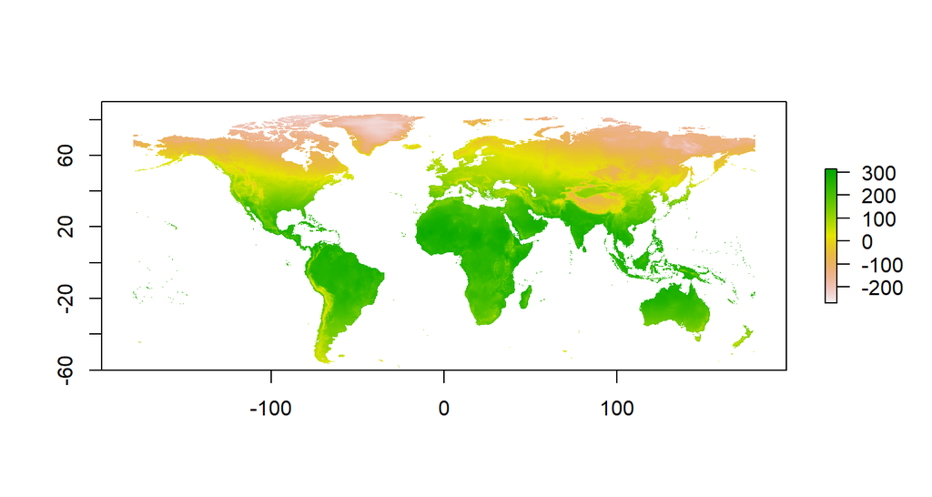

```r
# get climate data
climate <- getData ('worldclim', var='bio', res=10)
plot(climate$bio1)
```

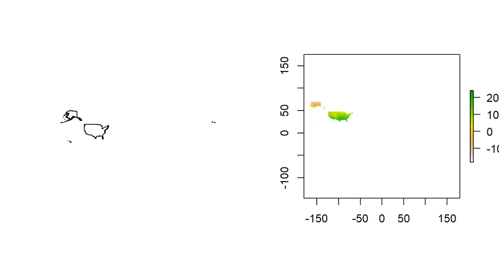

```r
par( mfrow=c(1,2) )
# Country level boundaries of US
myRaster <- getData('GADM', country='USA', level=0)
plot(myRaster)
# crop the us climate data
clippedRaster <- mask(climate$bio1, myRaster)
plot(clippedRaster)
```

Create the interactive version of it:

```r
# Show clipped raster
pal <- colorNumeric(c("#0C2C84", "#41B6C4", "#FFFFCC"),
                    values(clippedRaster),
                    na.color = "transparent")
map_leaflet <- leaflet() %>%
  addTiles() %>%
  addRasterImage(clippedRaster, colors = pal, opacity = 0.8)  %>%
  addLegend(pal = pal, values = values(clippedRaster),
            title = "Anual Mean Temperature Values in US")
map_leaflet
```

[interactive chart not shown]

## More resources

*Climate data*

http://www.diva-gis.org/climate http://www.worldclim.org/

*Elevation data*

http://www.cgiar-csi.org/data/srtm-90m-digital-elevation-database-v4-1#download http://srtm.csi.cgiar.org/SELECTION/inputCoord.asp

*Land use data*

http://due.esrin.esa.int/page_globcover.php

*Population raster*

http://sedac.ciesin.columbia.edu/data/sets/browse?facets=theme:population&facets=data-type:raster

[figure not shown]

Thanks!

https://www.esteban-correa.info/

https://maurosc3ner.github.io/6085cintrolandscapeecology/

[\(@maurosc3ner\)](https://twitter.com/maurosc3ner?lang=en)